# 薪資結構對組織績效之影響-MLB

陳立昀、顏逢晉、褚凡瑋、張宜森

2019年1月10日

# **ABSTRACT**

### 薪資結構對於組織績效的影響，一直以來都是一個備受關注的議題之一，在如今聯盟的制度之下，薪資上限的限制已經漸漸地被放寬，然而付出的薪資越高是否就能得到更好的績效，是許多球隊都面臨的最重要的問題之一。

### 本研究藉由MLB最近十個球季(2008年球季到2017年球季)的資料作為研究樣本，探討球隊的薪資結構對於球隊的勝率的影響，利用最小平方法(OLS)分析

#### 。實證結果如下: 當球隊總薪資越高，對球隊勝率有正向的顯著影響。當球隊薪資不均度越高，對球隊勝率有負向影響。球隊總人數對球隊勝率有正向影響，上一季勝率對當季球隊勝率有正向的顯著影響，上一季得失分比對球隊勝率有正向的顯著影響。

# **MOTIVATION**

### 受到課堂《魔球》(MONEYBALL)電影的 「棒球數據分析」導向所吸引，以經濟理論模型找到最佳選擇，取代了過去球探商品化球員所構建的球團策略

### 棒球身為全球代表性運動之一，尤其MLB制度成熟，歷史悠久，可做為薪資結構對團隊績效影響的代表性研究探討，歷史文獻不勝枚舉，研究資料齊全透明，想藉此嘗試

## **美國職棒大聯盟MLB介紹**

### 美國職棒大聯盟(MLB；Major League Baseball)歷史可追朔至 1876 年，為全世界歷史最悠久的職業棒球聯盟，目前共有 30 支球隊所組成，包含美國聯盟與國家聯盟各15 隊，而兩個聯盟各自按照球隊所屬地理位置，分成東區、中區、西區，每區各 5 支球隊3。所有球隊每年都要進行162場的例行賽，例行賽後六個分區戰績第一名的球隊，與除了六個分區冠軍之外，兩個聯盟各自戰績最佳的兩支外卡球隊(Wild Card)，一共10 支球隊晉級季後賽，兩聯盟各自進行三輪的淘汰賽，獲勝的兩支聯盟冠軍球隊，即可進行世界大賽(World Series)爭奪年度總冠軍。

### 美聯東區：紐約洋基、波士頓紅襪、多倫多藍鳥、坦帕灣光芒、巴爾的摩金鶯

### 美聯中區：芝加哥白襪、底特律老虎、堪薩斯皇家、明尼蘇達雙城、克里夫蘭印地安人

### 美聯西區：洛杉磯天使、德州遊騎兵、西雅圖水手、奧克蘭運動家、休士頓太空人

### 國聯東區：紐約大都會、華盛頓國民、費城費城人、邁阿密馬林魚、亞特蘭大勇士

### 國聯中區：芝加哥小熊、聖路易紅雀、匹茲堡海盜、辛辛那提紅人、密爾瓦基釀酒人

### 國聯西區：洛杉磯道奇、舊金山巨人、聖地牙哥教士、科羅拉多落磯、亞利桑那響尾蛇

[figure not shown]

# **LITERATURE REVIEW**

### 陳冠語(2010) 實證結果顯示不論是nba或mlb當球隊的總薪資越高，則所對應的球隊勝率會有正向的顯著影響。而mlb球隊的薪資不均度與球隊勝率之間的結果也存在顯著負相關。

### 黃淑貞(2012) 球隊薪資總和與勝場數間為顯著正相關。球隊總薪資排名與球隊戰績排名間為顯著正相關。

### 黃瑞雯(2016) 實證結果顯示投手方面防禦率越低，表示績效越好，結果顯示投手在季初獲得較高月薪，則當季的防禦率越低。打者方面，當季初月薪越高，則當季調整後的攻擊指數也會較高。此外，出場次數、球隊勝率與攻擊指數有正向關係，打者年紀越輕，表現較佳。守備方面，當投手旱季初獲得較高的月薪，當季守備率並沒有特別的影響。不過出場次數越多、固定守備位置的選手，守備率較佳。

### 許元俊(2016) 實證結果顯示，無論是對於球隊勝率或是售票率，皆與薪資總額有正向之關係，以及皆與薪資不均度有負向之關係，依賴高薪球員程度與球員流動率亦分別與勝率有正向以及負向關係，但皆與售票率較無關聯。

### 吳嘉倫(2012) 團體運動實證結果顯示，NFL以及NHL當球隊薪資總額越高，對應的球隊績效會有正向的顯著影響，且為了提升球隊績效的前提之下，NFL以及NHL薪資結構皆呈現偏向支持公平理論，從球員位置探討，實證結果皆顯示球員的薪資結構偏向支持公平理論；個人運動實證結果顯示:PGA及ITF皆因為獎金金額越高，所對應個別績效有正向顯著影響，因此PGA及ITF皆呈現獎金結構偏向支持競賽理論。

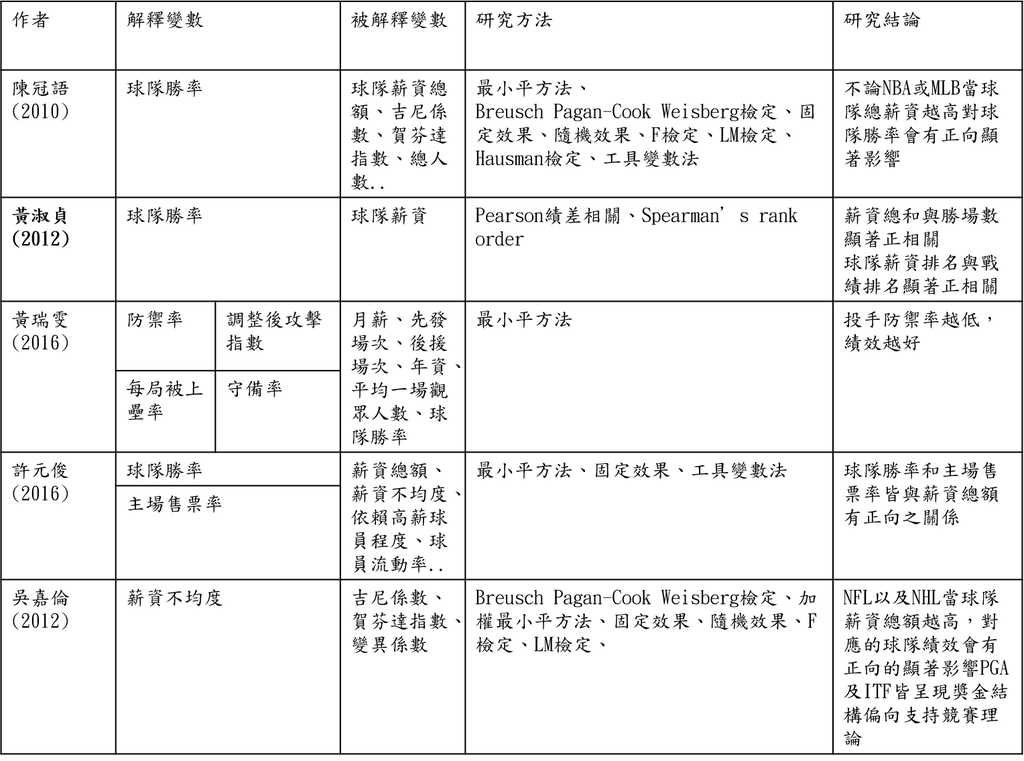

# **研究樣本與資料來源**

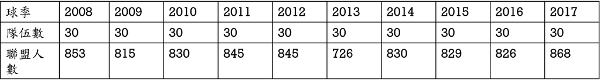

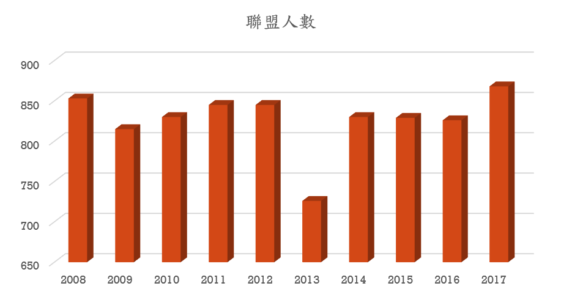

# **敘述統計**

#### MLB近十個球季的平均薪資資料整理

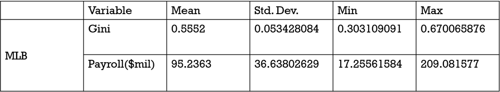

# **研究假說**

### 本研究以許元俊(2016)，「組織薪資結構與人員結構對組織績效之影響：以美國職棒大聯盟 MLB 為例」的研究做基礎，利用MLB近十個球季(2008-2017)的資料做出以下假說:

#### 。球隊薪資總額對球隊勝率有正向影響

#### 。薪資不均度對球隊勝率有負向影響

#### 。上一季的得失分比對球隊勝率有正向影響

#### 。上一季球隊勝率對當季球隊勝率有正向影響

## –**備註**–

### 薪資資料因考量通膨因素及時間影響，已先行以貨幣購買力進行換算，以2008年為基期，換算其他年度

#### 貨幣購買力:

#### 單位貨幣購買商品或換取勞務的能力。其大小決定於貨幣價值與商品價值的對比關係；其變動與商品價格、服務費用水平的變動成反比，與貨幣價值的變動成正比。在貨幣價值不變的條件下，商品價格、服務收費降低時，單位貨幣購買力就提高；反之，則下降。

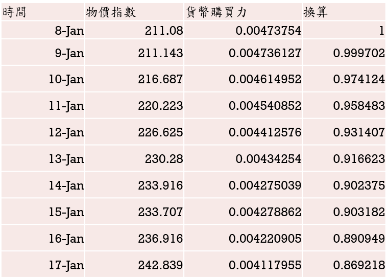

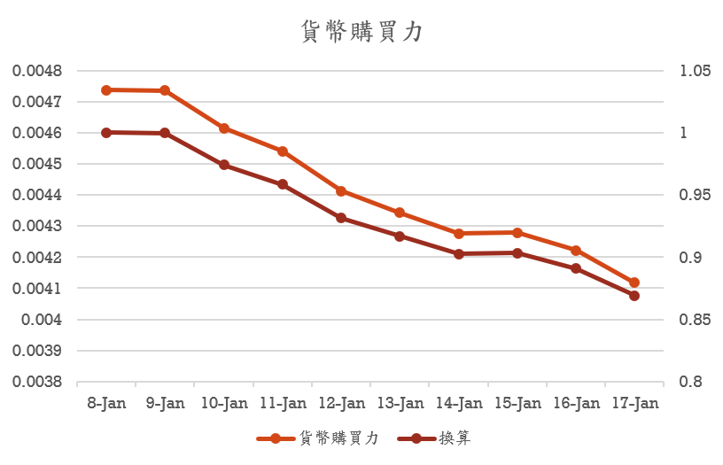

# **研究模型**

[figure not shown]

# **變數說明**

## 被解釋變數

### 球隊勝率(WP):

### 衡量球隊績效的方式有很多，如觀眾人數、財政收入、球隊勝率等等。而文獻中多以球隊勝率為績效指標，我們也以球隊勝率當作績效指標。

## 解釋變數

### 公式參照:

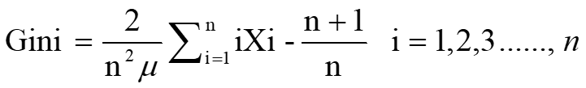

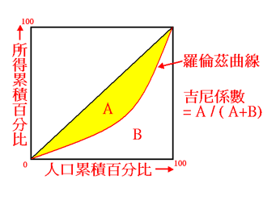

### 上一季的勝率(Lastwp):

### 指的是上一個球季內球隊的勝率

### 上一季的得失分比(Goal average):

### 指的是上一個球季內球隊的總得分比上總失分比

### 球隊人數(Nop):

### 指的是當季球隊內的總人數，由於正式上場的比賽名單有限，球員為了競爭先發位置而有可能造成更好的表現，對球隊的勝率有未知的影響

# **自變數之定義與預期結果**

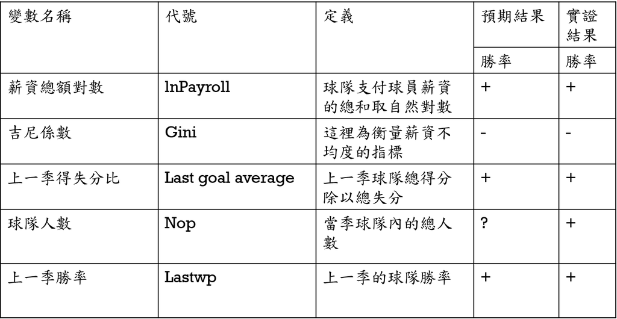

# **研究方法**

### 本研究以MLB(30隊)(2008~2017年)十個球季的300筆資料，先利用相關係數探討解釋變數對被解釋變數的相關性，接著再利用最小平方法套用在模型上，來分析球隊內的薪資結構及薪資不均度對於球隊勝率的影響，並加入年度虛擬變數以及得失分比率的影響。

### 相關係數

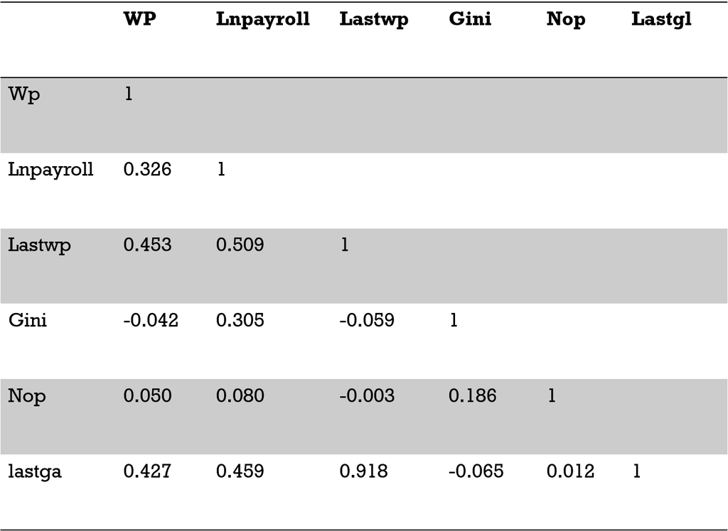